# Project 1

Allen Crane, Nicholas Cellini, Heber Nielsen, Quincy Roundtree, Chris Graves

June 26, 2018

## Set working directory and get data files

```r
setwd("C:\\Users\\allen\\Documents\\SMU Data Science\\MSDS6306 - Doing Data Science\\Lecture 5")
beers1.df <- read.csv("Beers.csv", header=TRUE, sep = ",")
beers.df <- read.csv("Enhanced_beers.csv", header=TRUE, sep = ",")
breweries.df <- read.csv("Breweries.csv", header=TRUE, sep = ",")
```

## 1. How many breweries are present in each state?

```r
library(plyr)
library(lattice)
brewery_count <- table(breweries.df$State)
brewery_count
```

```
##
##  AK  AL  AR  AZ  CA  CO  CT  DC  DE  FL  GA  HI  IA  ID  IL  IN  KS  KY
##   7   3   2  11  39  47   8   1   2  15   7   4   5   5  18  22   3   4
##  LA  MA  MD  ME  MI  MN  MO  MS  MT  NC  ND  NE  NH  NJ  NM  NV  NY  OH
##   5  23   7   9  32  12   9   2   9  19   1   5   3   3   4   2  16  15
##  OK  OR  PA  RI  SC  SD  TN  TX  UT  VA  VT  WA  WI  WV  WY
##   6  29  25   5   4   1   3  28   4  16  10  23  20   1   4
```

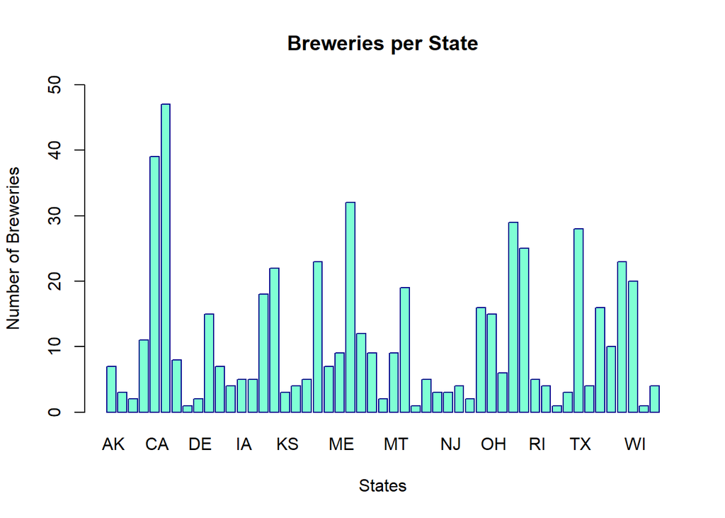

```r
barplot(brewery_count, border = "darkblue", col = "aquamarine", main = "Breweries per State", xlab = "States", ylab="Number of Breweries", ylim = range(pretty(c(0, brewery_count))))
```

## 2. Merge beer data with the breweries data. Print the first 6 observations and the last six observations to check the merged file.

#### First create a new variable “Brewery_id” (copy of “Brew_ID”) that can merge both files

#### Clean up column names

```r
breweries.df$Brewery_id <- breweries.df$Brew_ID
MergeBeerBreweries1 <- merge(x=beers1.df, y=breweries.df, by="Brewery_id", all=TRUE)
names(MergeBeerBreweries1) <- c("Brewery_ID", "Beer_Name", "Beer_ID", "ABV", "IBU", "Style", "Ounces", "Brew_ID", "Brewery_Name", "City", "State")
MergeBeerBreweries <- merge(x=beers.df, y=breweries.df, by="Brewery_id", all=TRUE)
names(MergeBeerBreweries) <- c("Brewery_ID", "Beer_Name", "Beer_ID", "ABV", "IBU", "Style", "Ounces", "Brew_ID", "Brewery_Name", "City", "State")
head(MergeBeerBreweries)
```

```
##   Brewery_ID     Beer_Name Beer_ID   ABV IBU
## 1          1  Get Together    2692 0.045  50
## 2          1    Stronghold    2688 0.060  25
## 3          1   Parapet ESB    2687 0.056  47
## 4          1    Wall's End    2690 0.048  19
## 5          1       Pumpion    2689 0.060  38
## 6          1 Maggie's Leap    2691 0.049  26
##                                 Style Ounces Brew_ID       Brewery_Name
## 1                        American IPA     16       1 NorthGate Brewing
## 2                     American Porter     16       1 NorthGate Brewing
## 3 Extra Special / Strong Bitter (ESB)     16       1 NorthGate Brewing
## 4                   English Brown Ale     16       1 NorthGate Brewing
## 5                         Pumpkin Ale     16       1 NorthGate Brewing
## 6                  Milk / Sweet Stout     16       1 NorthGate Brewing
##          City State
## 1 Minneapolis    MN
## 2 Minneapolis    MN
## 3 Minneapolis    MN
## 4 Minneapolis    MN
## 5 Minneapolis    MN
## 6 Minneapolis    MN
```

```r
tail(MergeBeerBreweries)
```

```
##      Brewery_ID                 Beer_Name Beer_ID   ABV IBU
## 2405        556             Pilsner Ukiah      98 0.055  NA
## 2406        557           Snapperhead IPA      51 0.068  63
## 2407        557         Porkslap Pale Ale      49 0.043  35
## 2408        557  Heinnieweisse Weissebier      52 0.049  10
## 2409        557         Moo Thunder Stout      50 0.049  35
## 2410        558 Urban Wilderness Pale Ale      30 0.049  NA
##                        Style Ounces Brew_ID                  Brewery_Name
## 2405         German Pilsener     12     556         Ukiah Brewing Company
## 2406            American IPA     12     557       Butternuts Beer and Ale
## 2407 American Pale Ale (APA)     12     557       Butternuts Beer and Ale
## 2408              Hefeweizen     12     557       Butternuts Beer and Ale
## 2409      Milk / Sweet Stout     12     557       Butternuts Beer and Ale
## 2410        English Pale Ale     12     558 Sleeping Lady Brewing Company
##               City State
## 2405         Ukiah    CA
## 2406 Garrattsville    NY
## 2407 Garrattsville    NY
## 2408 Garrattsville    NY
## 2409 Garrattsville    NY
## 2410     Anchorage    AK
```

## 3. Report the number of NA’s in each column.

#### Sources: Nick Hould Github page: https://github.com/nickhould/craft-beers-dataset; http://www.untappd.com; http://www.beeradvocate.com

```r
summary(MergeBeerBreweries1)
```

```
##    Brewery_ID                     Beer_Name       Beer_ID
##  Min.   :  1.0   Nonstop Hef Hop       :  12   Min.   :   1.0
##  1st Qu.: 94.0   Dale's Pale Ale       :   6   1st Qu.: 808.2
##  Median :206.0   Oktoberfest           :   6   Median :1453.5
##  Mean   :232.7   Longboard Island Lager:   4   Mean   :1431.1
##  3rd Qu.:367.0   1327 Pod's ESB        :   3   3rd Qu.:2075.8
##  Max.   :558.0   Boston Lager          :   3   Max.   :2692.0
##                  (Other)               :2376
##       ABV               IBU                                    Style
##  Min.   :0.00100   Min.   :  4.00   American IPA                  : 424
##  1st Qu.:0.05000   1st Qu.: 21.00   American Pale Ale (APA)       : 245
##  Median :0.05600   Median : 35.00   American Amber / Red Ale      : 133
##  Mean   :0.05977   Mean   : 42.71   American Blonde Ale           : 108
##  3rd Qu.:0.06700   3rd Qu.: 64.00   American Double / Imperial IPA: 105
##  Max.   :0.12800   Max.   :138.00   American Pale Wheat Ale       :  97
##  NA's   :62        NA's   :1005     (Other)                       :1298
##      Ounces         Brew_ID                          Brewery_Name
##  Min.   : 8.40   Min.   :  1.0   Brewery Vivant            :  62
##  1st Qu.:12.00   1st Qu.: 94.0   Oskar Blues Brewery       :  46
##  Median :12.00   Median :206.0   Sun King Brewing Company  :  38
##  Mean   :13.59   Mean   :232.7   Cigar City Brewing Company:  25
##  3rd Qu.:16.00   3rd Qu.:367.0   Sixpoint Craft Ales       :  24
##  Max.   :32.00   Max.   :558.0   Hopworks Urban Brewery    :  23
##                                  (Other)                   :2192
##            City          State
##  Grand Rapids:  66    CO    : 265
##  Portland    :  64    CA    : 183
##  Chicago     :  55    MI    : 162
##  Indianapolis:  43    IN    : 139
##  San Diego   :  42    TX    : 130
##  Boulder     :  41    OR    : 125
##  (Other)     :2099   (Other):1406
```

```r
summary(MergeBeerBreweries)
```

```
##    Brewery_ID                     Beer_Name       Beer_ID
##  Min.   :  1.0   Nonstop Hef Hop       :  12   Min.   :   1.0
##  1st Qu.: 94.0   Dale's Pale Ale       :   6   1st Qu.: 808.2
##  Median :206.0   Oktoberfest           :   6   Median :1453.5
##  Mean   :232.7   Longboard Island Lager:   4   Mean   :1431.1
##  3rd Qu.:367.0   1327 Pod's ESB        :   3   3rd Qu.:2075.8
##  Max.   :558.0   Boston Lager          :   3   Max.   :2692.0
##                  (Other)               :2376
##       ABV               IBU                                    Style
##  Min.   :0.00100   Min.   :  4.00   American IPA                  : 424
##  1st Qu.:0.05000   1st Qu.: 21.00   American Pale Ale (APA)       : 245
##  Median :0.05600   Median : 35.00   American Amber / Red Ale      : 133
##  Mean   :0.05975   Mean   : 42.79   American Blonde Ale           : 108
##  3rd Qu.:0.06700   3rd Qu.: 64.00   American Double / Imperial IPA: 105
##  Max.   :0.12800   Max.   :138.00   American Pale Wheat Ale       :  97
##  NA's   :55        NA's   :891      (Other)                       :1298
##      Ounces         Brew_ID                          Brewery_Name
##  Min.   : 8.40   Min.   :  1.0   Brewery Vivant            :  62
##  1st Qu.:12.00   1st Qu.: 94.0   Oskar Blues Brewery       :  46
##  Median :12.00   Median :206.0   Sun King Brewing Company  :  38
##  Mean   :13.59   Mean   :232.7   Cigar City Brewing Company:  25
##  3rd Qu.:16.00   3rd Qu.:367.0   Sixpoint Craft Ales       :  24
##  Max.   :32.00   Max.   :558.0   Hopworks Urban Brewery    :  23
##  NA's   :2                       (Other)                   :2192
##            City          State
##  Grand Rapids:  66    CO    : 265
##  Portland    :  64    CA    : 183
##  Chicago     :  55    MI    : 162
##  Indianapolis:  43    IN    : 139
##  San Diego   :  42    TX    : 130
##  Boulder     :  41    OR    : 125
##  (Other)     :2099   (Other):1406
```

## 4. Compute the median alcohol content and international bitterness unit for each state. Plot a bar chart to compare.

#### First create a median function so we can group by State

#### Plot bar chart of ABV by State

#### Plot box plot of ABV by State

#### Plot bar chart of IBU by State

#### Plot box plot of IBU by State

```r
MedianBeerStat <- function(x) {
  c(median = median(x[which(!is.na(x))]))
}
tapply(MergeBeerBreweries$ABV, MergeBeerBreweries$State, MedianBeerStat)
```

```
##     AK     AL     AR     AZ     CA     CO     CT     DC     DE     FL
## 0.0560 0.0600 0.0520 0.0550 0.0580 0.0605 0.0600 0.0625 0.0550 0.0570
##     GA     HI     IA     ID     IL     IN     KS     KY     LA     MA
## 0.0550 0.0540 0.0555 0.0565 0.0580 0.0580 0.0500 0.0625 0.0520 0.0540
##     MD     ME     MI     MN     MO     MS     MT     NC     ND     NE
## 0.0580 0.0510 0.0610 0.0560 0.0520 0.0580 0.0550 0.0570 0.0500 0.0555
##     NH     NJ     NM     NV     NY     OH     OK     OR     PA     RI
## 0.0550 0.0460 0.0620 0.0600 0.0550 0.0580 0.0600 0.0560 0.0570 0.0550
##     SC     SD     TN     TX     UT     VA     VT     WA     WI     WV
## 0.0550 0.0600 0.0570 0.0550 0.0400 0.0565 0.0550 0.0555 0.0520 0.0620
##     WY
## 0.0500
```

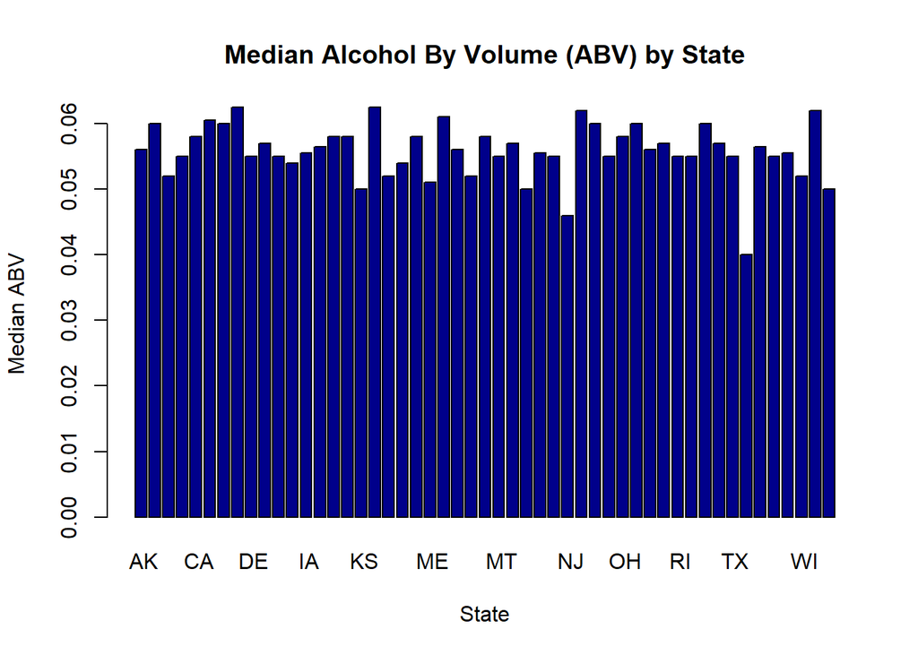

```r
MedianABV <- tapply(MergeBeerBreweries$ABV, MergeBeerBreweries$State, MedianBeerStat)
barplot(MedianABV, main="Median Alcohol By Volume (ABV) by State", xlab="State", ylab="Median ABV", col="darkblue")
```

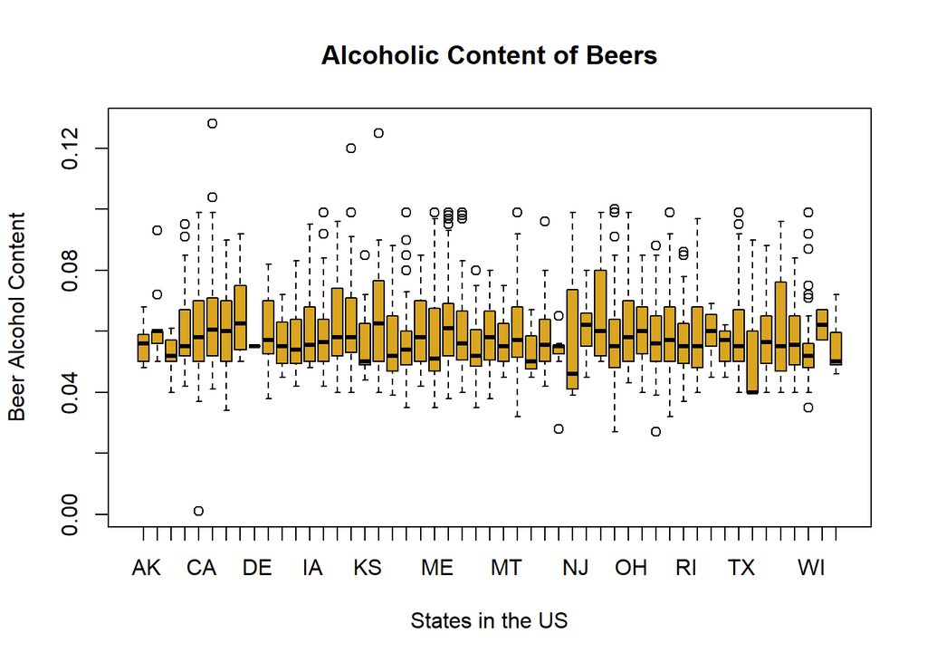

```r
boxplot (ABV ~ State, data = MergeBeerBreweries, col = "goldenrod", main = "Alcoholic Content of Beers", subtitle = "Beers Brewed in Each State and the District of Columbia", xlab = "States in the US", ylab = "Beer Alcohol Content")
```

```r
tapply(MergeBeerBreweries$IBU, MergeBeerBreweries$State, MedianBeerStat)
```

```
##   AK   AL   AR   AZ   CA   CO   CT   DC   DE   FL   GA   HI   IA   ID   IL
## 46.0 39.5 39.0 20.5 42.0 40.0 65.0 47.5 52.0 52.5 41.5 22.5 26.0 39.0 33.0
##   IN   KS   KY   LA   MA   MD   ME   MI   MN   MO   MS   MT   NC   ND   NE
## 33.0 22.0 38.0 36.0 35.0 28.0 42.0 32.5 44.0 24.0 45.0 40.0 32.0 32.0 32.0
##   NH   NJ   NM   NV   NY   OH   OK   OR   PA   RI   SC   SD   TN   TX   UT
## 48.5 34.5 72.0 41.0 46.5 42.0 35.0 40.0 36.0 24.0 32.5 40.0 37.0 34.0 34.0
##   VA   VT   WA   WI   WV   WY
## 43.5 31.5 39.5 19.5 57.5 21.0
```

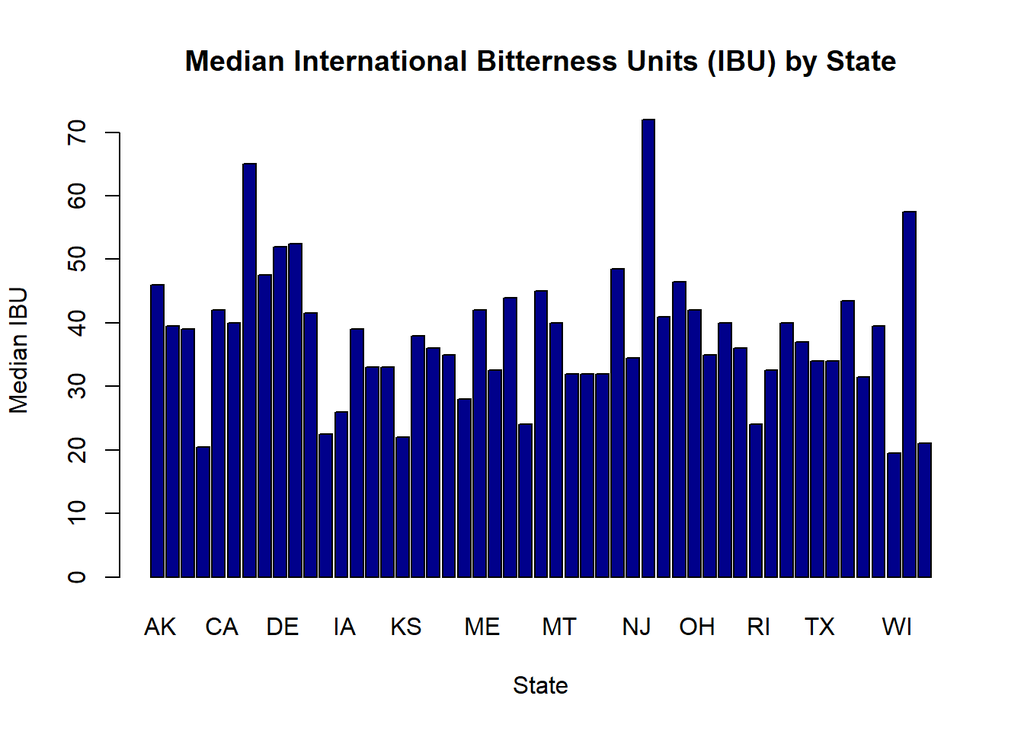

```r
MedianIBU <- tapply(MergeBeerBreweries$IBU, MergeBeerBreweries$State, MedianBeerStat)
barplot(MedianIBU, main="Median International Bitterness Units (IBU) by State", xlab="State", ylab="Median IBU", col="darkblue")
```

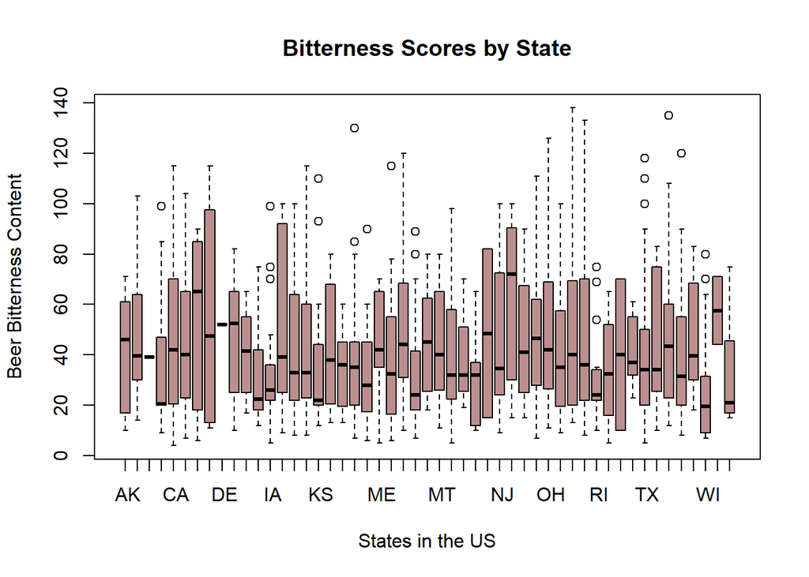

```r
boxplot (IBU ~ State, data = MergeBeerBreweries, col = "rosybrown", main = "Bitterness Scores by State", subtitle = "Beers Brewed in Each State and the District of Columbia", xlab = "States in the US", ylab = "Beer Bitterness Content")
```

## 5. Which state has the maximum alcoholic (ABV) beer? Which state has the most bitter (IBU) beer?

#### Colorado has the maximum alcoholic beer “Lee Hill Series Vol. 5 - Belgian Style Quadrupel Ale” (ABV 12.8%), in terms of individual beers, while Oregon has the most bitter beer “Bitter Bitch Imperial IPA” (IBU 138), in terms of individual beers.

#### Using the median ABV and IBU data respectivly, Washington, DC and Kentucky are tied with the highest median alcoholic beer (ABV 6.25%), while New Mexico has the highest median bitterness (IBU 72).

```r
MergeBeerBreweries[which.max(MergeBeerBreweries$ABV),]
```

```
##     Brewery_ID                                            Beer_Name
## 375         52 Lee Hill Series Vol. 5 - Belgian Style Quadrupel Ale
##     Beer_ID   ABV IBU            Style Ounces Brew_ID
## 375    2565 0.128  NA Quadrupel (Quad)   19.2      52
##                Brewery_Name    City State
## 375 Upslope Brewing Company Boulder    CO
```

```r
MergeBeerBreweries[which.max(MergeBeerBreweries$IBU),]
```

```
##      Brewery_ID                 Beer_Name Beer_ID   ABV IBU
## 1858        375 Bitter Bitch Imperial IPA     980 0.082 138
##                               Style Ounces Brew_ID            Brewery_Name
## 1858 American Double / Imperial IPA     12     375 Astoria Brewing Company
##         City State
## 1858 Astoria    OR
```

```r
which.max(MedianABV)
```

```
##  DC
##   8
```

```r
MedianABV[c(8,18)]
```

```
##     DC     KY
## 0.0625 0.0625
```

```r
which.max(MedianIBU)
```

```
##  NM
##  33
```

```r
MedianIBU[33]
```

```
##  NM
##  72
```

## 6. Summary statistics for the ABV variable.

```r
summary(MergeBeerBreweries$ABV)
```

```
##    Min. 1st Qu.  Median    Mean 3rd Qu.    Max.    NA's
## 0.00100 0.05000 0.05600 0.05975 0.06700 0.12800      55
```

## 7. Is there an apparent relationship between the bitterness of the beer and its alcoholic content? Draw a scatter plot.

#### There appears to be a slight relationship between ABV and IBU (R^2 = 0.4461)

#### (Note: slightly lower than our original analysis)

#### The regression equation is (IBU = -34.66 + 1293.22*ABV)

#### For every 0.01 point increase in ABV, IBU increases by ~12.93

#### (Note: slighlty higher than before)

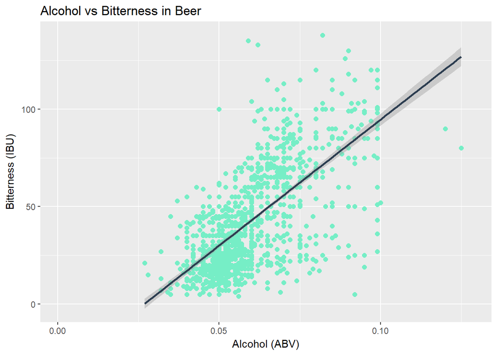

```r
attach(MergeBeerBreweries)
library(ggplot2)
r <- ggplot(MergeBeerBreweries, na.rm = TRUE, aes (x = ABV, y = IBU)) + geom_point (color = "aquamarine2", size = 2) + geom_smooth (method = lm, color = '#2C3D50')
r + ggtitle("Alcohol vs Bitterness in Beer") + xlab("Alcohol (ABV)") + ylab("Bitterness (IBU)")
```

```r
relation <- lm(IBU~ABV)
print(summary(relation))
```

```
##
## Call:
## lm(formula = IBU ~ ABV)
##
## Residuals:
##     Min      1Q  Median      3Q     Max
## -79.313 -12.171  -0.794  14.055  93.363
##
## Coefficients:
##             Estimate Std. Error t value Pr(>|t|)
## (Intercept)   -34.66       2.27  -15.27   <2e-16 ***
## ABV          1293.22      36.97   34.98   <2e-16 ***
## ---
## Signif. codes:  0 '***' 0.001 '**' 0.01 '*' 0.05 '.' 0.1 ' ' 1
##
## Residual standard error: 19.37 on 1517 degrees of freedom
##   (891 observations deleted due to missingness)
## Multiple R-squared:  0.4464, Adjusted R-squared:  0.4461
## F-statistic:  1223 on 1 and 1517 DF,  p-value: < 2.2e-16
```

## Conclusion

### With its high octane ABV of 12% and its subtle IBU of 33, we believe our FrankenBeer will make its mark in these new markets.